# Twitter API - Superclásico

#### *Authors:* Ronit Yoari & Orel Swisa

#### *Date*: April 13, 2016

#### *The API Dataset based [Twitter](https://twitter.com) - Connect Orel_Swisa Twitter account*

### *Data Description*

- This report provide detailed **hashtag** data from twitter about the **Superclásico - Real Madrid VS Barcelona** football match, which took place on April 2, 2016.
- The statistics relate only to tweets that contain the **Superclásico** hashtag.

### *Data Example - Reading first data records*

```
## [1] "Using direct authentication"
```

```
## [[1]]
## [1] "Cortesagustina7: RT @JuanRenaudoOk: #Recibimiento #RiverPlate #Superclasico #Increible #ElMasGrandeLejos \u26aa️\xed\xa0\xbd\xed\xb4\xb4\u26aa️ https://t.co/zko4oJ5rxC \xed\xa0\xbd\xed\xb1\x8d"
##
## [[2]]
## [1] "NaveirasJota: RT @JuanRenaudoOk: #Recibimiento #RiverPlate #Superclasico #Increible #ElMasGrandeLejos \u26aa️\xed\xa0\xbd\xed\xb4\xb4\u26aa️ https://t.co/zko4oJ5rxC \xed\xa0\xbd\xed\xb1\x8d"
##
## [[3]]
## [1] "ralphrod52: RT @JuanRenaudoOk: #Recibimiento #RiverPlate #Superclasico #Increible #ElMasGrandeLejos \u26aa️\xed\xa0\xbd\xed\xb4\xb4\u26aa️ https://t.co/zko4oJ5rxC \xed\xa0\xbd\xed\xb1\x8d"
##
## [[4]]
## [1] "YoVivoFutbol: #SuperClasico Video Boca Juniors 3-0 Atlético Rafaela Resumen Goles:  https://t.co/TxKQFVwfPx"
##
## [[5]]
## [1] "angelalealg: https://t.co/jbH6NRL0IW resumen del #Superclasico , increíble #KeylorNavas eres grande , orgullo tico felicidades"
##
## [[6]]
## [1] "Marcoshm8: RT @BasLepelaars: Somehow I feel Madrid will win tonight.... #barrea #superclasico #Cruijff #14 #modric https://t.co/QOenP0QeQW"
```

```
## [1] "Mon Apr 11 17:32:34 2016"
```

### *Summary*

#### *Some statistics on the tweets with **Superclásico** hashtag.*

- Most frequently used words in tweets with hashtag #SuperClasico:

```
## superclasico   realmadrid          del súperclásico    barcelona       madrid
##          325          106          105           97           80           71
```

- Sum of tweets with hashtag #SuperClasico that contains the word *Real Madrid* (ignore lowwer/uper case):

```
## [1] 171
```

- Sum of tweets with hashtag #SuperClasico that contains the word *Barcelona* (ignore lowwer/uper case)

```
## [1] 124
```

### *Wordcloud of tweets use with hashtag **#SuperClasico***

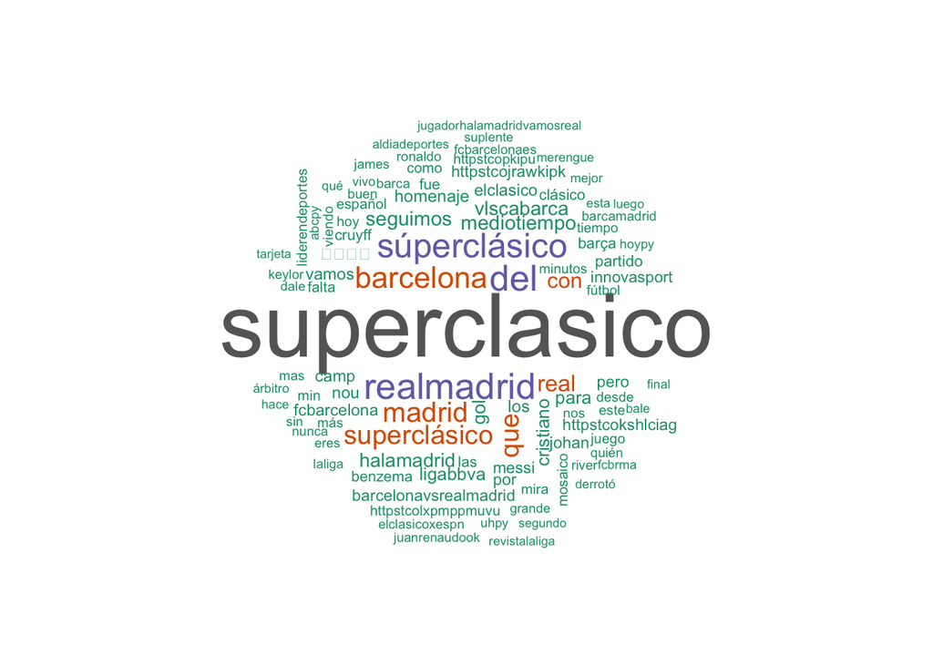

#### *Wordcloud Conclusions:*

As we can see from the wordcloud, the words with the greatest number of occurrences in the sample tweets are:  
- **Superclásico**.  
- **RealMadrid**.  
- **Barcelona**.

In that Superclásico, **Real Madrid beat Barcelona 2-1**, hence Real Madrid’s fans were more proud, and due to they tweeted more.  
More than that, as we can see acording to the wordcloud, the word **Cristiano** - that represented Real Madrid’s player “Cristiano Ronaldo”, is also have a big number of occurrences in the sample tweets. It resulted because he scored the winning goal in that match, that brought the victory to Real Madrid.

### *Network analysis of tweets that contain the hashtag **Superclásico***

#### Containing the following words:

- *Barcelona’s players* : Messi, Neymar, Luis Suarez  
  **MSN** = **M**essi, **S**uarez, **N**eymar.
- *Real Madrid’s players* : Cristiano Ronaldo, Gareth Bale, Karim Benzema  
  **BBC** = **B**ale, **B**enzema, **C**ristiano

```
##               Terms
## Terms          superclasico realmadrid barcelona messi neymar suarez cristiano bale benzema bbc msn
##   superclasico          327         58        47    11      1      1        26    4       8   2   2
##   realmadrid             58        106        41     7      0      0         4    0       5   0   0
##   barcelona              47         41        84     7      0      0         2    0       5   0   0
##   messi                  11          7         7    21      1      0         0    0       0   0   0
##   neymar                  1          0         0     1      6      0         0    0       3   0   0
##   suarez                  1          0         0     0      0      1         0    0       0   0   0
##   cristiano              26          4         2     0      0      0        30    1       3   0   0
##   bale                    4          0         0     0      0      0         1    7       0   0   0
##   benzema                 8          5         5     0      3      0         3    0      16   0   0
##   bbc                     2          0         0     0      0      0         0    0       0   2   2
##   msn                     2          0         0     0      0      0         0    0       0   2   2
```

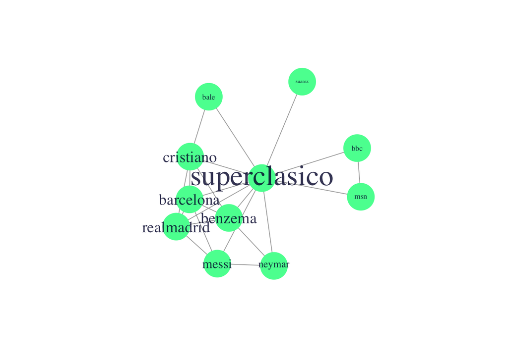

### *The graph below shows the **frequency** of tweets with #Superclásico*

### *durring the week of the Superclásico*

```
##
## 2016-04-02 2016-04-03 2016-04-04
##        937         40         42
```

```
##               User Tweets
## 183   danivigoblas     42
## 43  aldia_Deportes     15
## 88   Armandojose18     10
## 515     manuelmr11     10
## 41     albirrojapy      8
## 44         aldiagt      7
```

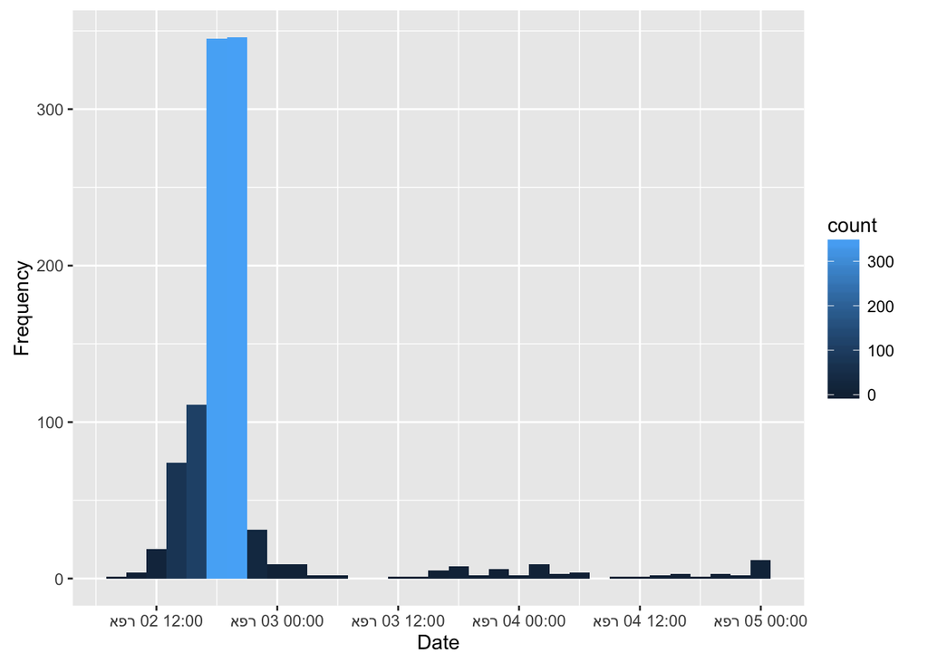

### *Summary, Conclusions and Recommendations for Further Research.*

In conclusion, this report shows that can we link between terms, in the context of social networks posts, like Twitter. We can analyze **trends** according to the **time and content** of posts on the social networks in extensive and varied issues, - in particular in sports as demonstrated in the above report

Our recommendation for further research, is to cross-check between more than one issues, to see if there is a common ground between them.